# Case Study:

### To create a classifier that can be implemented easily on streaming sensor data to detect Shake gesture

#### Datasets:

Sensor.csv has data phone sensors recorded every 100 ms (10Hz frequency).

- timestamp(ms) : Unix Timestamp in milliseconds.
- acceleration_x(g) : Acceleration along phone's x axis (measured in g)
- acceleration_y(g) : Acceleration along phone's y axis (measured in g)
- acceleration_z(g) : Acceleration along phone's z axis (measured in g)
- roll(rad) : Roll angle representing phone's attitude (orientation)
- pitch(rad) : Pitch angle representing phone's attitude (orientation)
- yaw(rad) : Yaw angle representing phone's attitude (orientation)
- angular_velocity_x(rad/sec) : Angular velocity around x axis (passing thru phones center along smaller edge)
- angular_velocity_y(rad/sec) : Angular velocity around y axis (passing thru phones center along longer edge)
- angular_velocity_z(rad/sec) : Angular velocity around z axis (passing thru phones center emerging out of phone )

lbl.csv contains 2 types of labels with time interval:

- Label 0 : Represents start of Shake gesture
- Label 1 : Indicates end of Shake gesture

#### Approch Overview:

- MasterData Preparation: Lables has been mapped to sensor data based on the timestamp interval.
- Performed descriptive analysis:
  - Box Plot for outlier detection
  - Pair plots to understand the relationship between all the features
  - Correlation matrix
- Models: Post feature engineering below models were developed
  - Logistic Regression
  - Decision Tree
  - Random Forest
  - XGBoost

#### Model Observations:

Refer each Model section

#### Recomendation:

Based on F1 score: Random Forest model is best with trainF1Score : 0.62 and testF1Score : 0.50

### Importing modules

```python
# Intractive notebook
from IPython.core.interactiveshell import InteractiveShell
InteractiveShell.ast_node_interactivity = 'all'
import warnings
warnings.filterwarnings('ignore')
#pd.set_option("display.max_columns",50)
```

```python
import pandas as pd
import numpy as np
import matplotlib.pyplot as plt
import re
from sklearn.model_selection import train_test_split
from sklearn.linear_model import LogisticRegression
from sklearn.tree import DecisionTreeClassifier,plot_tree
from sklearn.ensemble import RandomForestClassifier, StackingClassifier
from sklearn.preprocessing import StandardScaler,MinMaxScaler,MaxAbsScaler
from sklearn.model_selection import cross_val_score,GridSearchCV,StratifiedKFold,RepeatedStratifiedKFold,RandomizedSearchCV
from sklearn.metrics import accuracy_score,auc,recall_score,precision_score,precision_recall_curve,confusion_matrix,\
plot_confusion_matrix,plot_precision_recall_curve,plot_roc_curve,classification_report,roc_auc_score,f1_score
from xgboost import XGBClassifier
from sklearn.pipeline import make_pipeline,Pipeline

import seaborn as sns
sns.set(style="darkgrid") #white, dark, whitegrid, darkgrid, ticks
```

### User Defined Functions:

```python
def data_info(df):
    # Basic health check of data
    # args:
        # df : dataset
    # return: dataset
    df_info = pd.DataFrame(df.isna().sum(),columns = ['Null_count'])
    df_info['Non_Null_count'] = df_info.index.map(df.notna().sum())
    df_info['N_unique'] = df_info.index.map(df.nunique())
    df_info['D_types'] = df_info.index.map(df.dtypes)
    df_info['Blank_count'] = df_info.index.map((df=='').sum())
    return df_info
```

```python
def rem_xsd_more(data_col,th=3):
    # Function to tag observation as outlier based on predefined threshold in terms of standard deviations
    # args:
        # data_col: data columns
        # th: standard deviation as threshold
    # returns: True if outlier , False if non-outlier
    mean = data_col.mean()
    std = data_col.std()
    return((data_col-mean)/std>th)
```

```python
def rem_xpctl_more(data_col,pctl_th=0.99):
    # Function to tag observation as outlier based on predefined threshold in terms of quantile
    # args:
        # data_col: data columns
        # th: percentile as threshold
    # returns: True if outlier , False if non-outlier
    pctl = data_col.quantile(pctl_th)
    return data_col>pctl
```

```python
path = "/Users/nirbhaysingh/Desktop/Learning Module NIRS/Projects/MoneyOnClick/Phone_shake_detection_assignment"
```

```python
import zipfile
zf = zipfile.ZipFile(f'{path}/data_analysis.zip')
zf.namelist()
```

```
['a.sensor.csv',
 '__MACOSX/',
 '__MACOSX/._a.sensor.csv',
 'cleaning.ipynb',
 '__MACOSX/._cleaning.ipynb',
 'a.lbl.csv',
 '__MACOSX/._a.lbl.csv',
 'p.sensor.csv',
 '__MACOSX/._p.sensor.csv',
 'instructions.txt',
 '__MACOSX/._instructions.txt',
 'm.sensor.csv',
 '__MACOSX/._m.sensor.csv',
 'm.lbl.csv',
 '__MACOSX/._m.lbl.csv',
 'p.lbl.csv',
 '__MACOSX/._p.lbl.csv']
```

### Reading sensor data and labels

```python
a_data = pd.read_csv(zf.open('a.sensor.csv'))
a_data['data_name'] = 'a'
m_data = pd.read_csv(zf.open('m.sensor.csv'))
m_data['data_name'] = 'm'
p_data = pd.read_csv(zf.open('p.sensor.csv'))
p_data['data_name'] = 'p'
a_lbl = pd.read_csv(zf.open('a.lbl.csv'),)
a_lbl['data_name'] = 'a'
m_lbl = pd.read_csv(zf.open('m.lbl.csv'))
m_lbl['data_name'] = 'm'
p_lbl = pd.read_csv(zf.open('p.lbl.csv'))
p_lbl['data_name'] = 'p'
f'shape of a_data : {a_data.shape} & shape of a_label : {a_lbl.shape}'
f'shape of m_data : {m_data.shape} & shape of a_label : {m_lbl.shape}'
f'shape of p_data : {p_data.shape} & shape of a_label : {p_lbl.shape}'
```

```
'shape of a_data : (71642, 11) & shape of a_label : (10, 3)'
```

```
'shape of m_data : (21325, 11) & shape of a_label : (328, 3)'
```

```
'shape of p_data : (70902, 11) & shape of a_label : (290, 3)'
```

```python
a_lbl.head(1)
```

|  | timestamp(ms) | label (0=start 1=end 2=cancel) | data_name |
| --- | --- | --- | --- |
| 0 | 1397019861612 | 0 | a |

### Master Data Prepration:

1. Concatinating all Datasets

```python
data = pd.concat([a_data,m_data,p_data], axis = 0).reset_index(drop = True).sort_values('timestamp(ms)')
target = pd.concat([a_lbl,m_lbl,p_lbl], axis = 0).reset_index(drop = True).sort_values('timestamp(ms)')
```

1. Changing column names

```python
data.columns = [re.sub(r'\(.*\)', '', i) for i in data.columns]
target.columns = [re.sub(r'\s*\(.*\)', '', i) for i in target.columns] #r'\([^)]*\)'
```

```python
data_info(data)# Basic summary of dataset
```

|  | Null_count | Non_Null_count | N_unique | D_types | Blank_count |
| --- | --- | --- | --- | --- | --- |
| timestamp | 0 | 163869 | 163802 | int64 | 0 |
| acceleration_x | 0 | 163869 | 12959 | float64 | 0 |
| acceleration_y | 0 | 163869 | 12035 | float64 | 0 |
| acceleration_z | 0 | 163869 | 12611 | float64 | 0 |
| roll | 0 | 163869 | 20171 | float64 | 0 |
| pitch | 0 | 163869 | 18183 | float64 | 0 |
| yaw | 0 | 163869 | 35487 | float64 | 0 |
| angular_velocity_x | 0 | 163869 | 19754 | float64 | 0 |
| angular_velocity_y | 0 | 163869 | 19754 | float64 | 0 |
| angular_velocity_z | 0 | 163869 | 19840 | float64 | 0 |
| data_name | 0 | 163869 | 3 | object | 0 |

```python
data_info(target)# Basic summary of dataset
```

|  | Null_count | Non_Null_count | N_unique | D_types | Blank_count |
| --- | --- | --- | --- | --- | --- |
| timestamp | 0 | 628 | 628 | int64 | 0 |
| label | 0 | 628 | 2 | int64 | 0 |
| data_name | 0 | 628 | 3 | object | 0 |

1. Mapping Target

```python
target['timestamp_tar']  = target['timestamp']
```

```python
base = pd.merge_asof(left = data,right = target, on = 'timestamp',\
                     allow_exact_matches=False,direction='forward')
```

```python
base = base[base.label.notna()] # 28 Observations are removed
base['timestamp_tar'] = base['timestamp_tar'].astype('int64',errors = 'ignore')
```

```python
base.head(2)
```

|  | timestamp | acceleration_x | acceleration_y | acceleration_z | roll | pitch | yaw | angular_velocity_x | angular_velocity_y | angular_velocity_z | data_name_x | label | data_name_y | timestamp_tar |
| --- | --- | --- | --- | --- | --- | --- | --- | --- | --- | --- | --- | --- | --- | --- |
| 0 | 1396948626717 | 0.0008 | 0.0038 | -0.0054 | -0.0217 | 0.0018 | 0.0000 | -0.0010 | -0.0010 | -0.0014 | m | 0.0 | m | 1396949162159 |
| 1 | 1396948626816 | 0.0025 | -0.0047 | -0.0093 | -0.0216 | 0.0019 | -0.0001 | -0.0022 | -0.0022 | 0.0023 | m | 0.0 | m | 1396949162159 |

```python
base.label.value_counts(normalize=True)*100
```

```
0.0    98.444834
1.0     1.555166
Name: label, dtype: float64
```

```python
data_info(base)# Basic summary of dataset
```

|  | Null_count | Non_Null_count | N_unique | D_types | Blank_count |
| --- | --- | --- | --- | --- | --- |
| timestamp | 0 | 163841 | 163774 | int64 | 0 |
| acceleration_x | 0 | 163841 | 12955 | float64 | 0 |
| acceleration_y | 0 | 163841 | 12035 | float64 | 0 |
| acceleration_z | 0 | 163841 | 12605 | float64 | 0 |
| roll | 0 | 163841 | 20159 | float64 | 0 |
| pitch | 0 | 163841 | 18179 | float64 | 0 |
| yaw | 0 | 163841 | 35472 | float64 | 0 |
| angular_velocity_x | 0 | 163841 | 19741 | float64 | 0 |
| angular_velocity_y | 0 | 163841 | 19741 | float64 | 0 |
| angular_velocity_z | 0 | 163841 | 19827 | float64 | 0 |
| data_name_x | 0 | 163841 | 3 | object | 0 |
| label | 0 | 163841 | 2 | float64 | 0 |
| data_name_y | 0 | 163841 | 3 | object | 0 |
| timestamp_tar | 0 | 163841 | 628 | int64 | 0 |

### Data Visualisation

1. Pair Plots

base['time_ymdhms'] = pd.to_datetime(base['timestamp'],unit='ms') # Convert Unix time to UTC time in ms

```python
vars1 = base.columns
pair_cols = base.head().drop(['timestamp', 'data_name_x', 'data_name_y','timestamp_tar'],axis = 1).columns
```

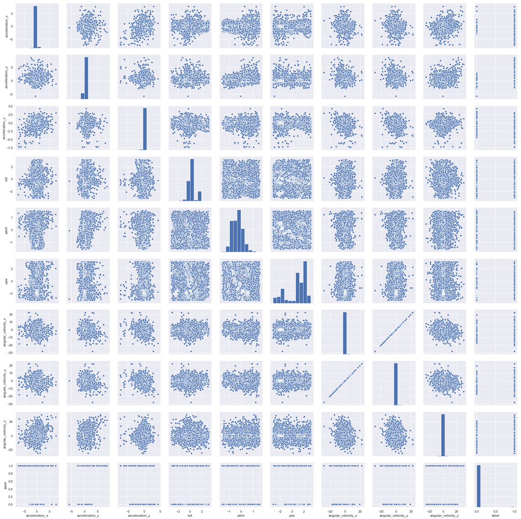

```python
sns.pairplot(base[pair_cols]);
```

1. Box Plot

```python
features_box = base.head().drop(['timestamp','data_name_x', 'label', 'data_name_y', 'timestamp_tar'],axis = 1).columns
features_box
```

```
Index(['acceleration_x', 'acceleration_y', 'acceleration_z', 'roll', 'pitch',
       'yaw', 'angular_velocity_x', 'angular_velocity_y',
       'angular_velocity_z'],
      dtype='object')
```

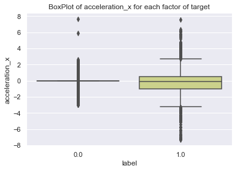

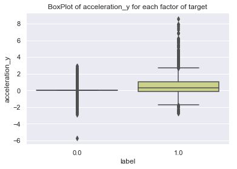

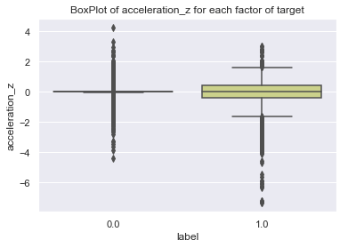

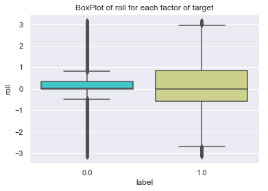

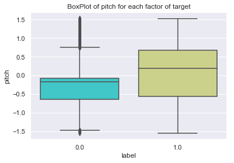

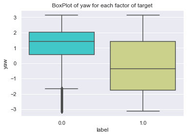

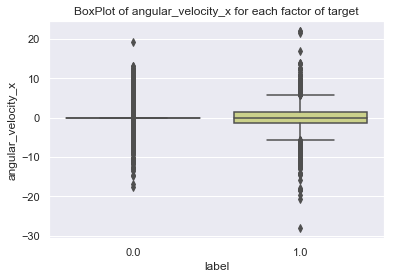

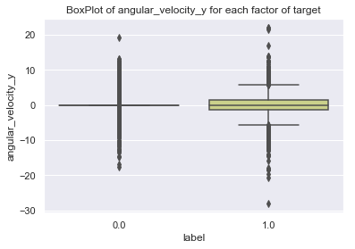

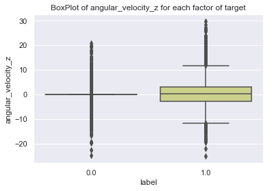

```python
for i in features_box:
    pfig = plt.figure();
    img = sns.boxplot(x='label',y=i,data=base,palette='rainbow').set_title(f'BoxPlot of {i} for each factor of target');
    fig = img.get_figure();
    fig.savefig(i);
    #fig.clf(); # run this for not printing figure
```

### Feature Engineering

```python
base.head(1)
```

|  | timestamp | acceleration_x | acceleration_y | acceleration_z | roll | pitch | yaw | angular_velocity_x | angular_velocity_y | angular_velocity_z | data_name_x | label | data_name_y | timestamp_tar |
| --- | --- | --- | --- | --- | --- | --- | --- | --- | --- | --- | --- | --- | --- | --- |
| 0 | 1396948626717 | 0.0008 | 0.0038 | -0.0054 | -0.0217 | 0.0018 | 0.0 | -0.001 | -0.001 | -0.0014 | m | 0.0 | m | 1396949162159 |

###### Calculating features which represent change in radian per unit metre i.e angular_acceleration/acceleration for each axis where angular_acceleration = angular_velocity / time(100ms) as the data is collected every 100ms

###### As value is very small, so multiplying it by 10000

```python
base['rad_per_mtr_x'] = 10000*(base.angular_velocity_x/100*0.001)/base.acceleration_x
base['rad_per_mtr_y'] = 10000*(base.angular_velocity_y/100*0.001)/base.acceleration_y
base['rad_per_mtr_z'] = 10000*(base.angular_velocity_z/100*0.001)/base.acceleration_z
```

```python
# Tackling Inf/NA values by replacing them by 0
base[['rad_per_mtr_x','rad_per_mtr_y','rad_per_mtr_z']] = base[['rad_per_mtr_x','rad_per_mtr_y','rad_per_mtr_z']].\
        replace([np.Inf,-np.Inf,np.nan],0)
base[['rad_per_mtr_x','rad_per_mtr_y','rad_per_mtr_z']].isin([np.Inf,-np.Inf,np.nan]).sum()
```

```
rad_per_mtr_x    0
rad_per_mtr_y    0
rad_per_mtr_z    0
dtype: int64
```

```python
base.head(2)
```

|  | timestamp | acceleration_x | acceleration_y | acceleration_z | roll | pitch | yaw | angular_velocity_x | angular_velocity_y | angular_velocity_z | data_name_x | label | data_name_y | timestamp_tar | rad_per_mtr_x | rad_per_mtr_y | rad_per_mtr_z |
| --- | --- | --- | --- | --- | --- | --- | --- | --- | --- | --- | --- | --- | --- | --- | --- | --- | --- |
| 0 | 1396948626717 | 0.0008 | 0.0038 | -0.0054 | -0.0217 | 0.0018 | 0.0000 | -0.0010 | -0.0010 | -0.0014 | m | 0.0 | m | 1396949162159 | -0.125 | -0.026316 | 0.025926 |
| 1 | 1396948626816 | 0.0025 | -0.0047 | -0.0093 | -0.0216 | 0.0019 | -0.0001 | -0.0022 | -0.0022 | 0.0023 | m | 0.0 | m | 1396949162159 | -0.088 | 0.046809 | -0.024731 |

### Correlation matrix

```python
features_cor = base.head().drop(['timestamp','data_name_x', 'label', 'data_name_y', 'timestamp_tar'],axis = 1).columns
features_cor
```

```
Index(['acceleration_x', 'acceleration_y', 'acceleration_z', 'roll', 'pitch',
       'yaw', 'angular_velocity_x', 'angular_velocity_y', 'angular_velocity_z',
       'rad_per_mtr_x', 'rad_per_mtr_y', 'rad_per_mtr_z'],
      dtype='object')
```

#### Plotting correlation matrix

```python
cor_mat = base[features_cor].corr()
```

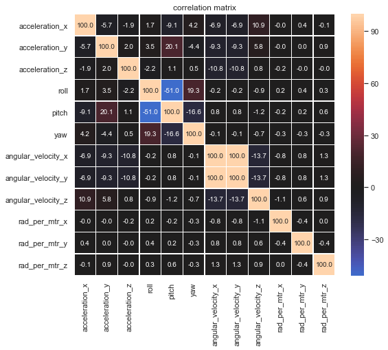

```python
#https://seaborn.pydata.org/generated/seaborn.heatmap.html
fig, ax = plt.subplots(figsize=(8.5,7)) ;
x = sns.heatmap(100*cor_mat, annot=True,fmt='.1f',center=0,linewidths = 0.25).set_title('correlation matrix')
plt.show()
```

#### Checking vars with high(0.65) correlation coeff

```python
var1 = []; var2 = []
for i in range(len(cor_mat.columns)):
    for j in range(len(cor_mat.index)):
        if (cor_mat.iloc[i,j] > 0.65) & (i>j):
            var1.append(cor_mat.columns[i]); var2.append(cor_mat.index[j])
high_cor_var = list(zip(var1,var2))
high_cor_var[0][0],high_cor_var[0][1]
```

```
('angular_velocity_y', 'angular_velocity_x')
```

#### Removing features with high correlation

```python
features = [a for a in features_cor if a not in [a for a,b in high_cor_var]] # removing var1
features
```

```
['acceleration_x',
 'acceleration_y',
 'acceleration_z',
 'roll',
 'pitch',
 'yaw',
 'angular_velocity_x',
 'angular_velocity_z',
 'rad_per_mtr_x',
 'rad_per_mtr_y',
 'rad_per_mtr_z']
```

#### Outlier Tagging

```python
base.reset_index(drop=True,inplace=True)
```

```python
sd_out = 1*(base[features].apply(rem_xsd_more).sum(axis = 1)>0)
sd_out.value_counts()
```

```
0    156024
1      7817
dtype: int64
```

```python
pctl_out = 1*(base[features].apply(rem_xpctl_more).sum(axis = 1)>0)
pctl_out.value_counts()
```

```
0    151103
1     12738
dtype: int64
```

```python
dev_base = base.loc[(base.index.isin(sd_out[sd_out==0].index))&(base.index.isin(pctl_out[pctl_out==0].index))].\
        reset_index(drop = True)
```

```python
import gc
del sd_out, pctl_out
gc.collect()
```

```
21378
```

```python
dev_base.label.value_counts(normalize=True)
base.label.value_counts(normalize=True)
```

```
0.0    0.995277
1.0    0.004723
Name: label, dtype: float64
```

```
0.0    0.984448
1.0    0.015552
Name: label, dtype: float64
```

##### event rate decreased from 1.5% to 0.5%; so event was happening mainly due to outliers, so deciding to keep outliers

### Modelling

```python
base.isna().sum()[base.isna().sum()>0]
```

```
Series([], dtype: int64)
```

```python
X_train, X_test, y_train, y_test = train_test_split(base[features],\
                base.label,test_size = 0.25, random_state =61, stratify = base.label)
```

```python
X_train.shape, X_test.shape
```

```
((122880, 11), (40961, 11))
```

```python
y_train.value_counts(normalize = True)
```

```
0.0    0.984448
1.0    0.015552
Name: label, dtype: float64
```

### Logistic Regression

```python
scl = StandardScaler()
logreg = LogisticRegression(max_iter = 10000, tol = 1e-6,random_state = 51,penalty  = 'l2',solver = 'sag',\
                            class_weight = {0:0.02,1:0.98},C = 0.5)# 'balanced'
```

```python
features_lr = ['acceleration_y'] # Post multiple iteration selected higher importance feature
```

```python
pipe = Pipeline([('sc', scl), ('lr', logreg)])
#pipe[0]
#pipe[1]
```

```python
pipe.fit(X_train[features_lr], y_train)
```

```
Pipeline(steps=[('sc', StandardScaler()),
                ('lr',
                 LogisticRegression(C=0.5, class_weight={0: 0.02, 1: 0.98},
                                    max_iter=10000, random_state=51,
                                    solver='sag', tol=1e-06))])
```

```python
estimator= pipe
pred_bin_tr = estimator.predict(X_train[features_lr])
pred_bin_te = estimator.predict(X_test[features_lr])
#confusion_matrix(y_train,pred_bin_tr)
f'train_roca : {roc_auc_score(y_train,estimator.predict_proba(X_train[features_lr])[:,1])} ; \
test_roca : {roc_auc_score(y_test,estimator.predict_proba(X_test[features_lr])[:,1])}'
f'train_f1_s : {f1_score(y_train,pred_bin_tr)} ; test_f1_s : {f1_score(y_test,pred_bin_te)}'
f'train_prec : {precision_score(y_train,pred_bin_tr)} ; test_prec : {precision_score(y_test,pred_bin_te)}'
f'train_reca : {recall_score(y_train,pred_bin_tr)} ; test_reca : {recall_score(y_test,pred_bin_te)}'
f'train_accu : {accuracy_score(y_train,pred_bin_tr)} ; test_accu : {accuracy_score(y_test,pred_bin_te)}'
f'train_conf : {confusion_matrix(y_train,pred_bin_tr)} ; test_conf : {confusion_matrix(y_test,pred_bin_te)}'
```

```
'train_roca : 0.671769958717146 ; test_roca : 0.693641200156285'
```

```
'train_f1_s : 0.3237410071942446 ; test_f1_s : 0.33671833244254407'
```

```
'train_prec : 0.2536339365173539 ; test_prec : 0.2552674230145867'
```

```
'train_reca : 0.4474097331240188 ; test_reca : 0.4945054945054945'
```

```
'train_accu : 0.9709309895833333 ; test_accu : 0.9697028881130831'
```

```
'train_conf : [[118453   2516]\n [  1056    855]] ; test_conf : [[39405   919]\n [  322   315]]'
```

### Decsion Tree

```python
dt = DecisionTreeClassifier(max_depth = 6,min_samples_split=10, min_samples_leaf=5,class_weight = {0:1,1:5})
dt.fit(X_train,y_train)
```

```
DecisionTreeClassifier(class_weight={0: 1, 1: 5}, max_depth=6,
                       min_samples_leaf=5, min_samples_split=10)
```

```python
estimator= dt
pred_bin_tr = estimator.predict(X_train)
pred_bin_te = estimator.predict(X_test)
f'train_roca : {roc_auc_score(y_train,estimator.predict_proba(X_train)[:,1])} ; \
test_roca : {roc_auc_score(y_test,estimator.predict_proba(X_test)[:,1])}'
f'train_f1_s : {f1_score(y_train,pred_bin_tr)} ; test_f1_s : {f1_score(y_test,pred_bin_te)}'
f'train_prec : {precision_score(y_train,pred_bin_tr)} ; test_prec : {precision_score(y_test,pred_bin_te)}'
f'train_reca : {recall_score(y_train,pred_bin_tr)} ; test_reca : {recall_score(y_test,pred_bin_te)}'
f'train_accu : {accuracy_score(y_train,pred_bin_tr)} ; test_accu : {accuracy_score(y_test,pred_bin_te)}'
f'train_conf : {confusion_matrix(y_train,pred_bin_tr)} ; test_conf : {confusion_matrix(y_test,pred_bin_te)}'
```

```
'train_roca : 0.9494801114525413 ; test_roca : 0.9377739485987675'
```

```
'train_f1_s : 0.4726379271833817 ; test_f1_s : 0.42555994729907776'
```

```
'train_prec : 0.4123148869836321 ; test_prec : 0.36662883087400683'
```

```
'train_reca : 0.5536368393511251 ; test_reca : 0.5070643642072213'
```

```
'train_accu : 0.9807861328125 ; test_accu : 0.9787114572398135'
```

```
'train_conf : [[119461   1508]\n [   853   1058]] ; test_conf : [[39766   558]\n [  314   323]]'
```

```python
dict(zip(features,100*dt.feature_importances_))
```

```
{'acceleration_x': 18.365378737230646,
 'acceleration_y': 72.32532809629524,
 'acceleration_z': 1.7585472444080583,
 'roll': 0.5126225572682692,
 'pitch': 1.1830716457771056,
 'yaw': 1.538232074608991,
 'angular_velocity_x': 0.5351235395678525,
 'angular_velocity_z': 3.515056638947843,
 'rad_per_mtr_x': 0.0,
 'rad_per_mtr_y': 0.0,
 'rad_per_mtr_z': 0.2666394658959941}
```

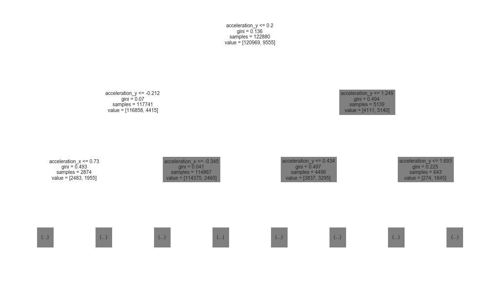

```python
fig, ax = plt.subplots(figsize=(17,10)) ;
x = plot_tree(dt,max_depth = 2,feature_names = features);
plt.show()
```

### Random Forest

```python
%%time
rf = RandomForestClassifier(n_estimators = 500,random_state =51,max_samples = 0.5,n_jobs = -1,max_depth = 8\
                            ,min_samples_split=10, min_samples_leaf=5,class_weight = {0:1,1:5})
rf.fit(X_train, y_train)
```

```
CPU times: user 1min 54s, sys: 1.28 s, total: 1min 55s
Wall time: 35.4 s
```

```python
estimator= rf
pred_bin_tr = estimator.predict(X_train)
pred_bin_te = estimator.predict(X_test)
f'train_roca : {roc_auc_score(y_train,estimator.predict_proba(X_train)[:,1])} ; \
test_roca : {roc_auc_score(y_test,estimator.predict_proba(X_test)[:,1])}'
f'train_f1_s : {f1_score(y_train,pred_bin_tr)} ; test_f1_s : {f1_score(y_test,pred_bin_te)}'
f'train_prec : {precision_score(y_train,pred_bin_tr)} ; test_prec : {precision_score(y_test,pred_bin_te)}'
f'train_reca : {recall_score(y_train,pred_bin_tr)} ; test_reca : {recall_score(y_test,pred_bin_te)}'
f'train_accu : {accuracy_score(y_train,pred_bin_tr)} ; test_accu : {accuracy_score(y_test,pred_bin_te)}'
f'train_conf : {confusion_matrix(y_train,pred_bin_tr)} ; test_conf : {confusion_matrix(y_test,pred_bin_te)}'
```

```
'train_roca : 0.9855668053293657 ; test_roca : 0.9795907855943001'
```

```
'train_f1_s : 0.6238174735670562 ; test_f1_s : 0.4991652754590985'
```

```
'train_prec : 0.6660724896019014 ; test_prec : 0.5329768270944741'
```

```
'train_reca : 0.586603872318158 ; test_reca : 0.46938775510204084'
```

```
'train_accu : 0.9889973958333333 ; test_accu : 0.9853519201191377'
```

```
'train_conf : [[120407    562]\n [   790   1121]] ; test_conf : [[40062   262]\n [  338   299]]'
```

```python
dict(zip(features,rf.feature_importances_))
```

```
{'acceleration_x': 0.2065560494779894,
 'acceleration_y': 0.28534606266226537,
 'acceleration_z': 0.08315507580629211,
 'roll': 0.031002857830683222,
 'pitch': 0.05304011111734068,
 'yaw': 0.025307567422321577,
 'angular_velocity_x': 0.1071238778105583,
 'angular_velocity_z': 0.1597750329790574,
 'rad_per_mtr_x': 0.014386542343331773,
 'rad_per_mtr_y': 0.014025856661311,
 'rad_per_mtr_z': 0.020280965888849253}
```

### XGBOOST

```python
%%time
xgb = XGBClassifier(max_depth = 8, learning_rate = 0.03,n_estimators = 500,n_jobs = -1,subsample=0.6,colsample_bytree= 0.9\
               ,scale_pos_weight = 10,reg_lambda = 50,random_state=0)
xgb.fit(X_train, y_train)
```

```
CPU times: user 1min 54s, sys: 662 ms, total: 1min 55s
Wall time: 1min 56s
```

```python
print(xgb.random_state)
```

```
0
```

```python
estimator= xgb
pred_bin_tr = estimator.predict(X_train)
pred_bin_te = estimator.predict(X_test)
f'train_roca : {roc_auc_score(y_train,estimator.predict_proba(X_train)[:,1])} ; test_roca : {roc_auc_score(y_test,estimator.predict_proba(X_test)[:,1])}'
f'train_f1_s : {f1_score(y_train,pred_bin_tr)} ; test_f1_s : {f1_score(y_test,pred_bin_te)}'
f'train_prec : {precision_score(y_train,pred_bin_tr)} ; test_prec : {precision_score(y_test,pred_bin_te)}'
f'train_reca : {recall_score(y_train,pred_bin_tr)} ; test_reca : {recall_score(y_test,pred_bin_te)}'
f'train_accu : {accuracy_score(y_train,pred_bin_tr)} ; test_accu : {accuracy_score(y_test,pred_bin_te)}'
f'train_conf : {confusion_matrix(y_train,pred_bin_tr)} ; test_conf : {confusion_matrix(y_test,pred_bin_te)}'
```

```
'train_roca : 0.998813336883421 ; test_roca : 0.9829524882984715'
```

```
'train_f1_s : 0.7684167684167683 ; test_f1_s : 0.4714964370546318'
```

```
'train_prec : 0.6287046287046287 ; test_prec : 0.37917860553963706'
```

```
'train_reca : 0.9879644165358451 ; test_reca : 0.6232339089481946'
```

```
'train_accu : 0.9907389322916667 ; test_accu : 0.9782720148433877'
```

```
'train_conf : [[119854   1115]\n [    23   1888]] ; test_conf : [[39674   650]\n [  240   397]]'
```

```python
dict(zip(features,xgb.feature_importances_))
```

```
{'acceleration_x': 0.113248974,
 'acceleration_y': 0.38911384,
 'acceleration_z': 0.045147374,
 'roll': 0.039377805,
 'pitch': 0.05754774,
 'yaw': 0.046229046,
 'angular_velocity_x': 0.073182255,
 'angular_velocity_z': 0.14519623,
 'rad_per_mtr_x': 0.028671207,
 'rad_per_mtr_y': 0.029625745,
 'rad_per_mtr_z': 0.032659873}
```

### KFOld CV

```python
estimator = rf
skf = StratifiedKFold(n_splits=5, shuffle = True,random_state = 51)
cv_result = cross_val_score(estimator=estimator, X=base[features], y=base.label, \
                                      cv=skf, scoring = 'f1')
cv_result
print("Full Accuracy: %0.2f(+/- %0.2f)" % (cv_result.mean(), cv_result.std()*2))
```

```
array([0.46941046, 0.48017149, 0.4962406 , 0.45435685, 0.48253968])
```

```
Full Accuracy: 0.48(+/- 0.03)
```

### selective RF

```python
feature_rf1 = ['acceleration_x', 'acceleration_y', 'acceleration_z','roll', 'pitch', 'yaw', 'angular_velocity_x', 'angular_velocity_z']
```

```python
%%time
rf1 = RandomForestClassifier()
rf1.fit(X_train[feature_rf1], y_train)
```

```
CPU times: user 27 s, sys: 194 ms, total: 27.2 s
Wall time: 27.3 s
```

```python
estimator= rf1
pred_bin_tr = estimator.predict(X_train[feature_rf1])
pred_bin_te = estimator.predict(X_test[feature_rf1])
f'train_roca : {roc_auc_score(y_train,estimator.predict_proba(X_train[feature_rf1])[:,1])} ; \
test_roca : {roc_auc_score(y_test,estimator.predict_proba(X_test[feature_rf1])[:,1])}'
f'train_f1_s : {f1_score(y_train,pred_bin_tr)} ; test_f1_s : {f1_score(y_test,pred_bin_te)}'
f'train_prec : {precision_score(y_train,pred_bin_tr)} ; test_prec : {precision_score(y_test,pred_bin_te)}'
f'train_reca : {recall_score(y_train,pred_bin_tr)} ; test_reca : {recall_score(y_test,pred_bin_te)}'
f'train_accu : {accuracy_score(y_train,pred_bin_tr)} ; test_accu : {accuracy_score(y_test,pred_bin_te)}'
f'train_conf : {confusion_matrix(y_train,pred_bin_tr)} ; test_conf : {confusion_matrix(y_test,pred_bin_te)}'
```

```
'train_roca : 1.0 ; test_roca : 0.9821795302632663'
```

```
'train_f1_s : 1.0 ; test_f1_s : 0.40719910011248595'
```

```
'train_prec : 1.0 ; test_prec : 0.7182539682539683'
```

```
'train_reca : 1.0 ; test_reca : 0.28414442700156983'
```

```
'train_accu : 1.0 ; test_accu : 0.9871341031713093'
```

```
'train_conf : [[120969      0]\n [     0   1911]] ; test_conf : [[40253    71]\n [  456   181]]'
```

```python
dict(zip(feature_rf1,rf1.feature_importances_))
```

```
{'acceleration_x': 0.1642270081768066,
 'acceleration_y': 0.16679493793727557,
 'acceleration_z': 0.11990415675158818,
 'roll': 0.09658852849277513,
 'pitch': 0.10665476895785617,
 'yaw': 0.09105732882833881,
 'angular_velocity_x': 0.1066491672018928,
 'angular_velocity_z': 0.1481241036534667}
```